# Practical II: epidemiological surveillance and modelling (spatial)

2nd/3rd February 2026

Pathogens move between different geographical units because of movements of animals or humans or other hosts. Spatial patterns of infectious disease transmission arise from heterogeneity in the landscape in which transmission occurs. In large and dense cities, for example, transmission intensity tends to be higher compared to rural areas. Spatial dispersal in ecology and epidemiology is often approximated by an exponential distribution, with the probability of transmission decaying with increasing distance $\propto exp(-d/a)$, where $a$ is a shape parameter (intrinsic to the pathogen or conditions for transmission) and $d$ is the distance between locations of interest.

For infectious diseases spreading among human populations, spatial dispersal rarely follows a continuous, uniform expansion. Instead, it is often shaped by the spatial organisation of cities and towns. Emerging infectious diseases, for example, tend to appear first in large urban agglomerations connected via air travel and subsequently spread to other major cities and rural counties, following patterns of local human movement. For the UK, for instance, the SARS-CoV-2 Omicron variant was first detected in London, a major hub for international travellers.

In this practical we will learn how to model continuous spatial spread using spatial kernels, before investigating the impact of human mobility on the spatial dispersal of infectious diseases. The code has been adapted from Chapter 11 of [Epidemics: Models and Data Using R](https://link.springer.com/book/10.1007/978-3-031-12056-5) by Ottar Bjornstad, and additional code can be found here: https://github.com/objornstad/epimdr/blob/master/rcode/chapter11code.r. There will be a 15 minute break after ca. 1h ½.

All the code for the practical is provided here, and you can copy & paste it in your own R script. Some of the questions will require you to make small changes in the code.

Load the packages of interest `epimdr`, `ggplot2`, `ncf`, `deSolve`, `dplyr`, `plot.matrix`, `reshape2`, `cowplot` using `library(<package_name>)`. You might have to install some of the packages yourself using `install.packages(<package_name>)`.

```r
library(epimdr)
library(ggplot2)
library(ncf)
library(deSolve)
library(plot.matrix)
library(reshape2)
library(dplyr)
library(cowplot)
```

If you are unable to load the `epimdr` package using the code above, please re-install the htmltools package (a dependency of `epimdr`).

```r
remove.packages('htmltools')
install.packages('htmltools')
```

## Practical II Questions

#### Q1: What determines the spatial spread of infectious diseases?

Contrast spread of plant diseases vs. human infectious diseases. Here a visualisation of [human movement patterns in the UK](https://www.science.org/cms/10.1126/science.abj0113/asset/c322ab29-d54d-42ef-8412-4e6789f1fcbd/assets/images/large/science.abj0113-f1.jpg) and [dynamics of measles diffusion in the UK](https://www.nature.com/articles/s41559-020-1186-6/figures/3).

And here you will find a figure describing the [continuous diffusion of Aedes albopictus in the USA and Europe](https://www.nature.com/articles/s41564-019-0376-y/figures/1).

**Model answer:**

The spatial spread of plant diseases tends to following a more continuous and homogeneous pattern, which can be approximated by a contiguous spatial kernel such as the exponential or Gaussian distribution. Whereas the spatial spread of human infectious diseases is often more heterogeneous and follows patterns of human mobility.

#### Q2: Plot the coordinates and infection status (0 for uninfected, 1 for infected, with different colours for the timing of infection) of a fungal rust pathogen (see picture below) on the Filipendula ulmaria wild plant. Summarise the data (number of infected locations in 1994, 1995 and how many remained uninfected).

[figure not shown]

Plant Infected With Rust

Context: Triphragmium ulmariae is a species of rust fungus in the family Sphaerophragmiaceae. It causes meadowsweet rust gall which develops as a chemically induced swelling, arising from the lower surface of the Filipendula ulmaria leaves. It has implications for the survival of the meadowsweet seedlings.

R code adapted from [Chapter 11, Epidemics: Models and Data in R, Ottar N. Bjornstad (ISBN 978-3-319-97487-3)](https://www.springer.com/gp/book/9783319974866).

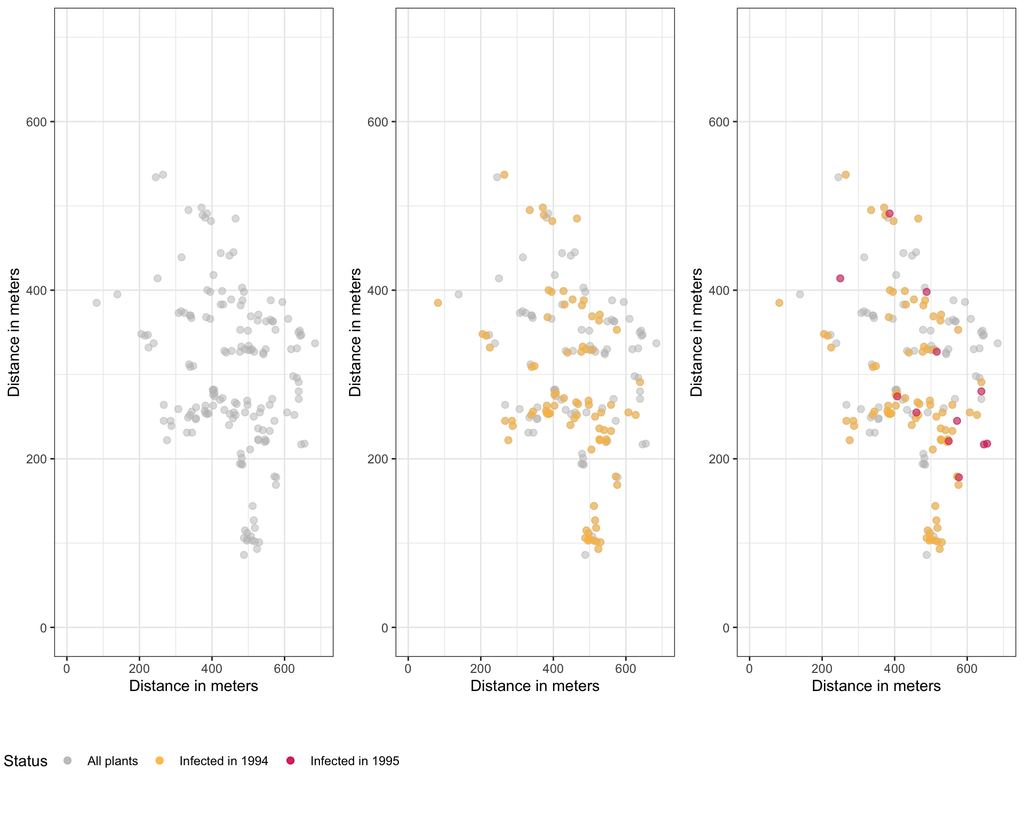

```r
data(filipendula)

cols <- c('Uninfected' = '#3a506b','Infected in 1994' = '#ffbc42',
          'Infected in 1995' = '#d81159', 'All plants' = "grey")

a1 <- ggplot() +
  geom_point(aes(X, Y,fill = 'All plants', color = 'All plants'),
             data = filipendula, shape = 21, size = 2,
             alpha = 0.5) +
  theme_bw() +
  xlim(0,700) + labs(x= "Distance in meters", y= "Distance in meters") +
  ylim(0,700) +
  scale_fill_manual(name = 'Infection Status',
                    values = cols) +
  scale_color_manual(name = 'Infection Status',
                     values = cols) +
  theme(legend.position='none')

a2 <- ggplot() +
  geom_point(aes(X, Y,fill = 'All plants', color = 'All plants'),
             data = filipendula, shape = 21, size = 2,
             alpha = 0.5) +
  geom_point(aes(X, Y,fill = 'Infected in 1994', color = 'Infected in 1994'),
             data = filipendula[filipendula$y94==1 & filipendula$y95 == 1, ],
             shape = 21, size = 2,
             alpha = 0.5) +
  theme_bw() +
  xlim(0,700) + labs(x= "Distance in meters", y= "Distance in meters") +
  ylim(0,700) +
  scale_fill_manual(name = 'Infection Status',
                    values = cols) +
  scale_color_manual(name = 'Infection Status',
                     values = cols) +
  theme(legend.position='none')

a3 <- ggplot() +
  geom_point(aes(X, Y,fill = 'All plants', color = 'All plants'),
             data = filipendula, shape = 21, size = 2,
             alpha = 0.5) +
  geom_point(aes(X, Y,fill = 'Infected in 1994', color = 'Infected in 1994'),
             data = filipendula[filipendula$y94==1 & filipendula$y95 == 1, ],
             shape = 21, size = 2,
             alpha = 0.5) +
  geom_point(aes(X, Y,fill = 'Infected in 1995', color = 'Infected in 1995'),
             data = filipendula[filipendula$y94==0 & filipendula$y95 == 1, ],
             shape = 21, size = 2,
             alpha = 0.5) +
  theme_bw() +
  xlim(0,700) + labs(x= "Distance in meters", y= "Distance in meters") +
  ylim(0,700) +
  scale_fill_manual(name = 'Infection Status',
                    values = cols) +
  scale_color_manual(name = 'Infection Status',
                     values = cols) +
  theme(legend.position = 'top')

legend_plot <- get_legend(a3)

a3_new <- a3 +
  theme(legend.position='none')

plot_grid(a1,a2,a3_new, legend_plot, ncol = 3,
          rel_heights = c(6, 1))
```

**Model answer:**

#### Q3: Calculate the distance between each pair of X and Y coordinate using the dist function in R. Visualise the distribution of distances and describe them (unit of distances is meters). Please also explain why we need a distance matrix.

We first have to calculate the distance between each pair of observations of Filipendula ulmaria across the island.

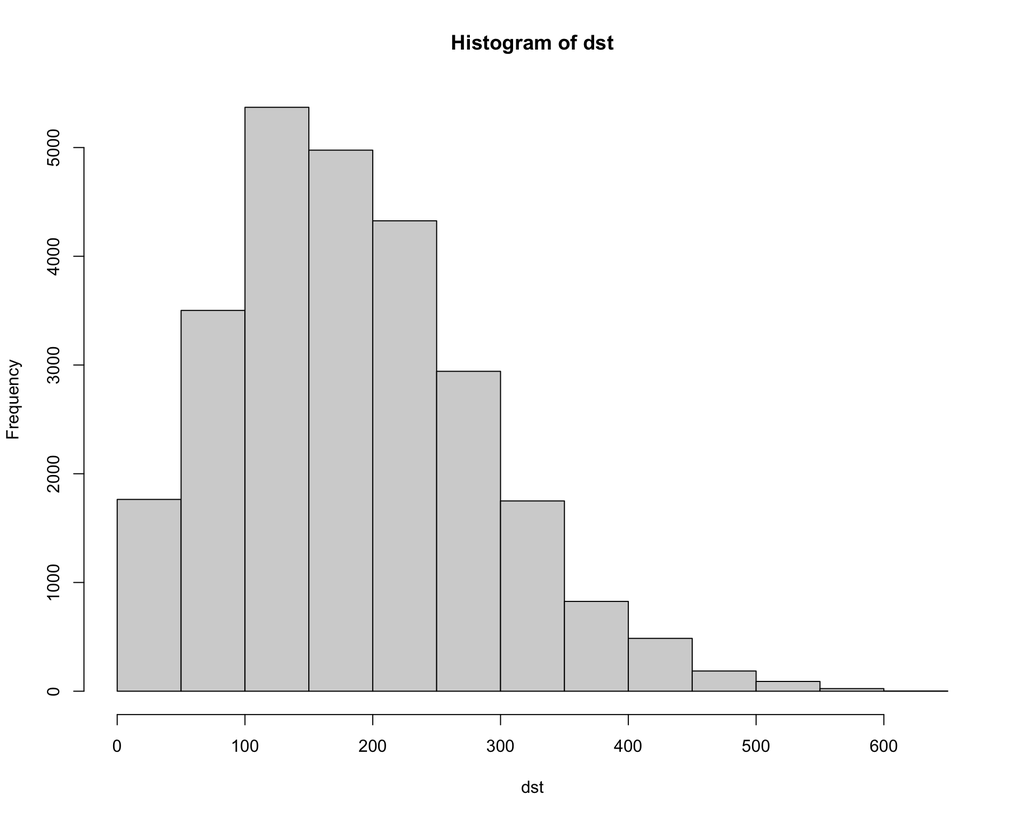

Frequency of distances between each datapoint in meters.

```r
dst = as.matrix(dist(filipendula[,c("X","Y")]))
hist(dst)
```

**Model answer:**

For calculating the force of spatial invasion, we need to calculate the distances between locations that are infected vs. those that are not. Predictors of invasion rely on a measure of closeness (here distance).

#### Q4: Calculate the force of spatial infection based on infected and uninfected plants. The likelihood of a uninfected plant becoming infected depends on the spatial force of invasion, which is given by its connectivity to all infected plants:

The force of infection experienced by an uninfected plant $i$ is proportional to $\sum_j z_j exp(-d_{ij}/a)$, where $z_j$ is the disease status $[0,1]$ in the previous year of any plant $j$ that is not $i$, and $d_{ij}$ is the distance between plant $i$ and $j$. $a$ is the shape parameter which governs how fast the force of infection (foi) decays with increasing distance. Also note that the summation is performed over all plants.

Explain in non-technical language how the force of invasion in 1995 is defined in this context and how changing the shape parameter $a$ can affect our estimation of the force of invasion.

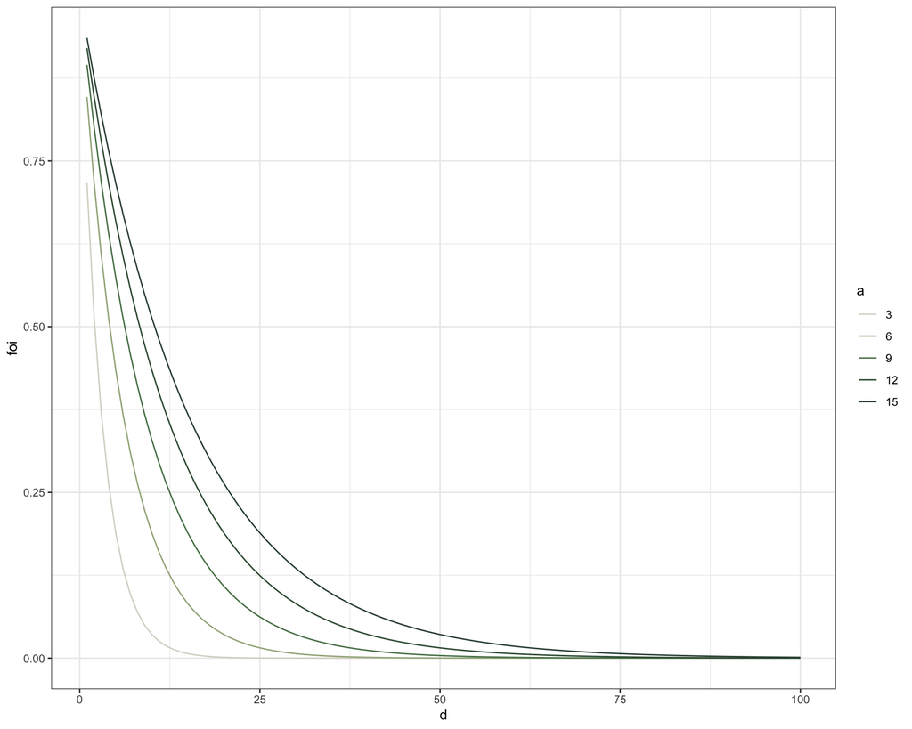

```r
max_dist <- 100
a <- rep(seq(3, 15, by = 3), each = max_dist)
d <- rep(seq(1, max_dist), length(unique(a)))
df <- cbind(a, d) %>%
    as.data.frame()
df <- df %>%
    mutate(foi = exp(-d/a))
ggplot(data = df, aes(x = d, y = foi)) + geom_line(aes(color = factor(a))) +
    scale_color_manual(values = c("#dad7cd", "#a3b18a", "#588157",
        "#3a5a40", "#344e41"), name = "a") + theme_bw()
```

Calculate force of invasion per location for 1995 based on data from 1994 for a given a. Try changing a and see how the mean foi changes.

```r
a = 10
foi = apply(exp(-dst/a) * filipendula$y94, 2, sum)
mean(foi)
```

```
## [1] 1.270177
```

**Model answer:**

Force of infection at any given location in 1995 is defined by how close infected locations are to non-infected locations. By increasing $a$, the force of infection also increases.

#### Q5: Now we like to compare how a spatial model estimating the dispersal compares to a model which is non-spatial (nullmod). To do so we create a second model in which the risk of infection is uniform across all locations. We then compare this model to the spatial model using the anova function in R (more details available here: https://www.youtube.com/watch?v=wEY1M8Pg0Wg).

Here our outcome is infection status in year 1995 and we want to know which one out of the following is the better predictor, using logistic regression (because our outcome is binary):

- Likelihood of becoming infected which is calculated by the connectivity of an uninfected plant to infected plants (spmod_exp in code)
- No information about connectivity between uninfected and infected plants (nullmod in code)

Explain the results of the anova test below. Please note, the residual deviance would be 0 if the model can perfectly explain the data. Lower residual deviance indicates a better model fit.

```r
# Using a GLM framework (more details on GLM can be found here:
# http://www.simonqueenborough.info/R/statistics/glm-binomial)
lfit = glm(y95 ~ foi, family = binomial(), data = filipendula)
lfit$deviance/2
```

```
## [1] 69.8527
```

```r
###################################################
a = seq(1,20, length = 1001)
llik = rep(NA, length(a))
for(i in 1:length(a)){
  foi = apply(exp(-dst/a[i])*filipendula$y94,2,sum)
  lfit = glm(y95~foi, family = binomial(), data = filipendula)
  llik[i] = lfit$deviance/2
}

###################################################
ahat = a[which.min(llik)]
foi = apply(exp(-dst/ahat)*filipendula$y94,2,sum)
spmod_exp = glm(y95~foi, family = binomial(), data = filipendula)
nullmod = glm(y95~1, family = binomial(), data = filipendula)
# Correct the df of the spmod_exp
spmod_exp$df.residual = spmod_exp$df.residual-1
anova(nullmod, spmod_exp, test = "Chisq")
```

```
## Analysis of Deviance Table
##
## Model 1: y95 ~ 1
## Model 2: y95 ~ foi
##   Resid. Df Resid. Dev Df Deviance  Pr(>Chi)
## 1       161     222.10
## 2       159     109.48  2   112.63 < 2.2e-16 ***
## ---
## Signif. codes:  0 '***' 0.001 '**' 0.01 '*' 0.05 '.' 0.1 ' ' 1
```

**Model answer:**

The spatial model has a lower residual deviance and is the better model compared to the null model (non-spatial).

#### Q6: We are now interested in whether a Gaussian kernel may be better in approximating the dispersal. To do so we create another model in which the force of infection is calculated using the Gaussian shape rather than exponential (see introduction).

Calculate the log-likelihood for the Gaussian kernel and compare the two models using AIC (see more details on AIC [here](https://www.ncbi.nlm.nih.gov/pmc/articles/PMC8187274/) section “Traditional null-hypothesis significance testing”) and visualise their kernels. Explain what the plot shows.

AIC is a function of:

- Model complexity (number of parameters used); it prefers a more parsimonious model
- Likelihood (how well the model reproduces the data)

Hence, the better model according to AIC is the one that explains the greatest amount of variation in the outcome using the fewest possible predictors. AIC = 2*(number of parameters)- 2*log(Likelihood). The model with the lower AIC is better.

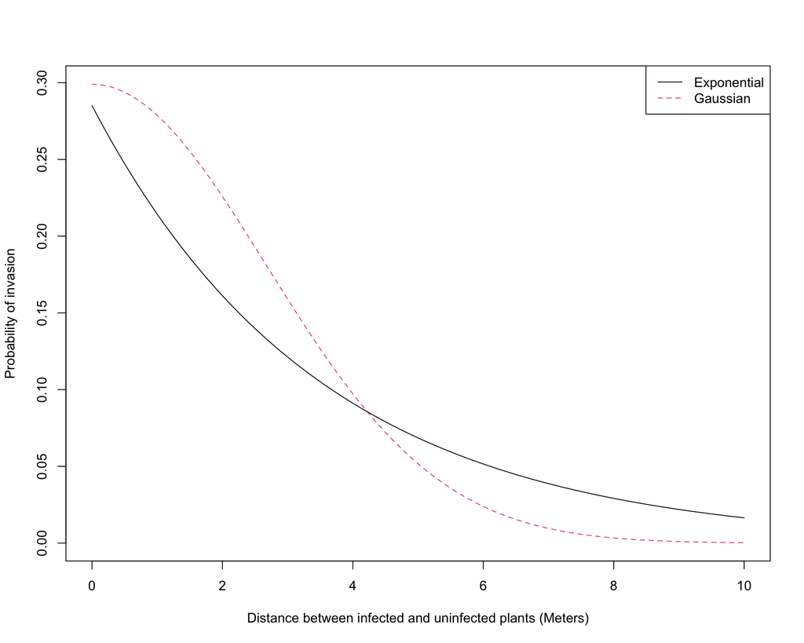

```r
a2 = seq(1, 20, length = 1001)
llik2 = rep(NA, length(a2))
for (i in 1:length(a2)) {
    foi2 = apply(exp(-(dst/a2[i])^2) * filipendula$y94, 2, sum)
    lfit2 = glm(y95 ~ foi2, family = binomial(), data = filipendula)
    llik2[i] = lfit2$deviance/2
}
ahat2 = a2[which.min(llik2)]
foi2 = apply(exp(-(dst/ahat2)^2) * filipendula$y94, 2, sum)
spmod_gaussian = glm(y95 ~ foi2, family = binomial(), data = filipendula)
spmod_gaussian$df.residual = spmod_gaussian$df.residual - 1

###################################################
curve((2/(ahat2 * gamma(1/2))) * exp(-((x/ahat2)^2)), 0, 10,
    col = 2, lty = 2, ylab = "Probability of invasion", xlab = "Distance between infected and uninfected plants (Meters)")
curve((1/(ahat) * gamma(1)) * exp(-x/ahat), 0, 10, add = TRUE)
legend("topright", c("Exponential", "Gaussian"), lty = c(1, 2),
    col = c(1, 2))
```

```r
###################################################
spmod_exp$aic
```

```
## [1] 113.4775
```

```r
spmod_gaussian$aic
```

```
## [1] 116.6538
```

**Model answer:**

The exponential model (spmod_exp) is favoured over the Gaussian model (spmod_gaussian).

#### Q7: Human mobility and its impact on spatial dispersal of epidemics.

The diffusion of human pathogens rarely follows simple patterns that can be approximated by the exponential or Gaussian kernels discussed above. The patterns of human mobility are more complex and follow patterns of transportation and human population aggregation. For example, it is more likely to travel to and from major population aggregation than to rural areas, even if the rural areas are closer to an individual’s home location. Consider the case of Oxford: on average people living in Oxford are more likely to travel to and from London than travel to let’s say, Cirencester. Cirencester is closer to Oxford but travel there via train takes ~2h, vs. 1h to central London. Chichester’s population is about 20k vs. London’s population is currently estimated at > 8M. So it is no surprise that human mobility patterns today are not strictly determined by distance.

Models approximating these data usually take into account the population of the origin and destination location, distance or travel time between them, and any other variables that may influence travel patterns such as the attractiveness of a population (shopping and work opportunities in cities). For the purpose of our practical we will consider the simplest of these models which is the Gravity model (Erlander and Stewart 1990: https://books.google.co.uk/books/about/The_Gravity_Model_in_Transportation_Anal.html?id=tId3PU1leR8C&redir_esc=y). The gravity model posits that movement volume between two communities depends inversely on distance, d, but bilinearly on the size, N, of the communities considered. More generally the model can be written as: $T_{ij}= \frac{N_i^aN_j^b}{d_{ij}^c}$ where $T_{ij}$ is the travel volume between locations $i$ and $j$, $N_i^a$ is the population at origin location $i$, $N_j^b$ is the population of destination location j and $d_{ij}^c$ is the distance between $i$ and $j$. $d_{ij}^c$ could also be the travel time between $i$ and $j$. $a$, $b$, $c$ are parameters fitted using empirical data.

Using a previously developed model by [Viboud et al. 2006](https://www.science.org/doi/10.1126/science.1125237) for the spatial spread of influenza in and between US cities, we will consider a simple version of the SIR model ignoring any susceptible recruitment (no births or deaths):

$\frac{dS_i}{dt} = -(\beta I_i + \sum_{j\neq i}t_{j,i}I_j)S_i$

$\frac{dI_i}{dt} = (\beta I_i + \sum_{j\neq i}t_{j,i}I_j)S_i-\gamma I_i$

$\frac{dR_i}{dt} = \gamma I_i$

where $t_{j,i}I_j$ is the gravity-weighted force of infection exerted by location $j$ on location $i$, with $t_{j,i}=T_{j,i}/P_i$ where $P_i$ is the population size of location $i$. $\beta$ is the transmission coefficient, $I$ is number of infected individuals, $S$ number of susceptibles, and $\gamma$ is the recovery rate.

Please use links provided in the text above and any other online resources to describe in your own words the Gravity model and the basic intuition behind it.

**Model answer:**

In analogy to Newton’s law of gravity, the gravity law assumes that the number of individuals travelling from $i$ to $j$ ($T_{ij}$) per unit time is proportional to some power of the population at the source and destination locations and decays with increasing distance between them. $a$ and $b$ are adjustable exponents and the distance deterrence function is chosen to fit the observed empirical data. The Gravity model was derived to describe human mobility patterns in a modern world where travel time may not necessarily scale linearly with distance but rather depends on the mode of transportation between locations.

#### Q8: We now translate the theory from above into code in R. This requires the R-package ‘deSolve’.

Explain in your own words the basics of the SIR model and its key assumptions. Should you be unfamiliar with it, there will be another practical going into the theory behind it. Otherwise please use the literature or watch a short section of this video by Prof. Grenfell https://youtu.be/AzVnN5cCFk4 (from minute ~4 to ~7). Some additional details can be found [here](https://royalsocietypublishing.org/doi/10.1098/rstb.2020.0263).

```r
SIR.space = function(t, y, pars){
  i = c(1:L)
  S = y[i]
  I = y[L+i]
  R = y[2*L+i]
  with(pars,{
    beta = beta[i]
    dS = -(beta*I + m*G%*%I)*S
    dI = (beta*I + m*G%*%I)*S - gamma*I
    dR = gamma*I
    list(c(dS, dI, dR))
  })
}
```

**Model answer:**

The classical model describing outbreaks is the SIR system. The standard SIR model is made up of ordinary differential equations describing the flow of hosts between the Susceptible, Infectious, and Recovered compartments.

The underlying assumptions are:

- The infection circulates in a population of size N with birth and death rates that balance each other out.
- The infection causes acute morbidity but no mortality. In the simple version of the model that means that we can ignore disease-induced mortality. This may not be realistic for example for Ebola.
- Individuals are susceptible from birth (doesn’t take into account demographic structure).
- Transmission of infection from infectious to susceptible individuals is controlled by a bilinear contact term. The assumption here is that susceptible and infected individuals mix at random.
- Infectiousness is assumed not to change during the course of the infection in an individual.
- Infected individuals become infectious immediately (no latent period).
- Those recovered are immune immediately and indefinitely.
- Chance of recovery or death does not change over the course of the outbreak or infection.
- Tends to be an oversimplification of complex biological mechanisms.

#### Q9: Now we want to estimate the interaction matrix for all US states using parameters estimated by Viboud et al. 2006, Science.

Generate matrix using the code below, visualise it, and explain what it shows (also refer back to Question 7; $a = 0.3$, $b = 0.6$, $c = 3$, and $G = T_{ij}$ in question 7):

```r
require(ncf)
data(usflu)
usdist = gcdist(usflu$Longitude, usflu$Latitude)

###################################################
gravity = function(a, b, c, pop, distance) {
    gravity = outer(pop^a, pop^b)/distance^c
    diag(gravity) = 0
    gravity
}
G = gravity(0.3, 0.6, 3, usflu$Pop, usdist)

class(G)
```

```
## [1] "matrix" "array"
```

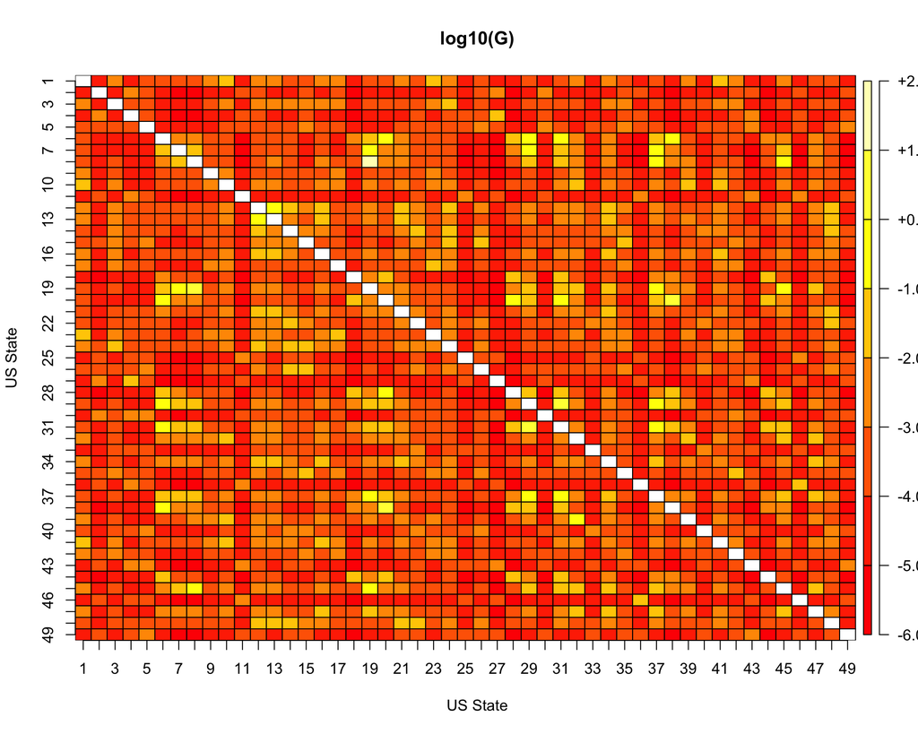

Spatial interaction matrix using parameters from Viboud et al. between all USA states.

```r
plot(log10(G), xlab = "US State", ylab = "US State")
```

**Model answer:**

Spatial interaction matrix here represents the relative connectivity between all states in the US.

#### Q10: What does G in the model above represent?

**Model answer:**

Spatial interaction matrix.

#### Q11: To estimate the spatial interaction matrix, what data do we need?

**Model answer:**

- Population per location
- Distance between locations

#### Q12: To simulate flu epidemic in the US, we need to define the reproduction number and recovery parameter. We assume all individuals to be susceptible for simplicity.

Generate model and outputs. Explain the figure and hypothesise why we observe subsequent waves of flu in different US states.

In the code below, we only visualised a selected few states.

```r
gamma = 1/3.5
R0=1.8
beta = R0*gamma/usflu$Pop
m = 1/1000/sum(usflu$Pop)
parms = list(beta = beta, m = m, gamma  =  gamma, G = G)
L = length(usflu$Pop)

head(usflu)
```

```
##   State Acronym      Pop Latitude Longitude Start Peak
## 1     1      AL  3755003  33.0015   -86.766    27   33
## 3     3      AZ  2332966  33.3735  -111.829    25   30
## 4     4      AR  2202789  35.0803   -92.577    28   32
## 5     5      CA 21955156  35.4586  -119.355    28   31
## 6     6      CO  2639909  39.5007  -105.204    28   31
## 7     7      CT  3143652  41.4949   -72.874    26   29
```

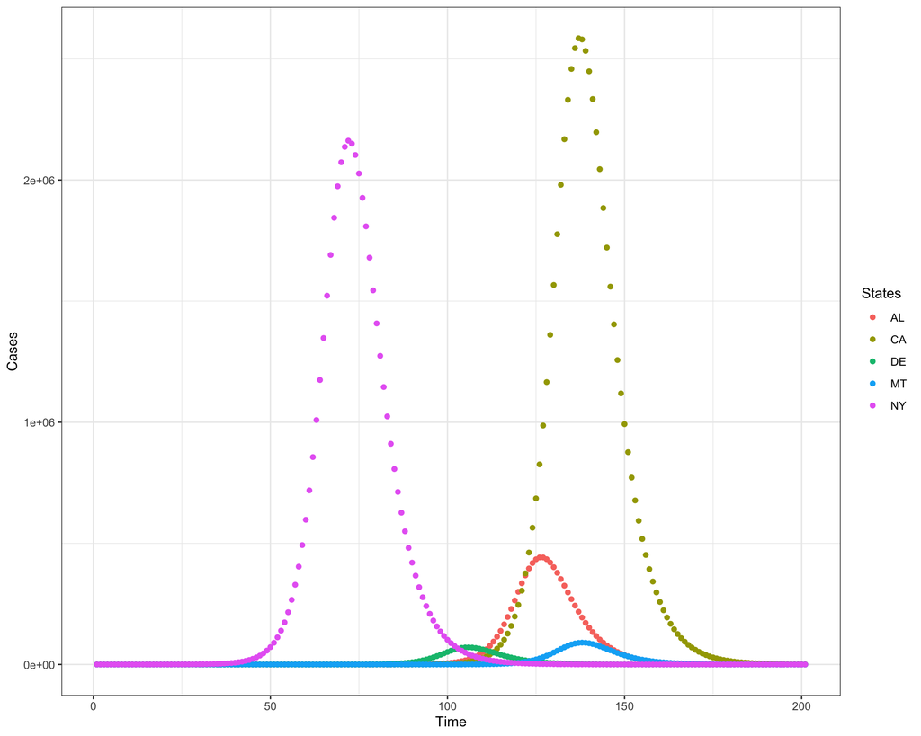

State level epidemics of Flu in the USA using a multipatch SIR model with parameters on spatial interactions based on Viboud et al. 2006. Initial case reported in NY state.

```r
S = usflu$Pop
R = I = rep(0, length(usflu$Pop))
usflu$State <- 1:nrow(usflu)
I[31] = 1 # State where to initialise the epidemic simulation
inits = c(S = S, I = I, R = R)


###################################################
times = 0:200
out = ode(inits, times, SIR.space, parms)
infected <- as.data.frame(out[,c(51:99)])
get_state_name <- as.data.frame(usflu)
names(infected) <- as.character(usflu$Acronym)
infected$time <- 1:201
infected_long <- melt(infected, id.vars="time")
state.name <- c("AL", "NY", "MT", "CA", "DE")
ggplot(infected_long %>%
    filter(variable %in% state.name), aes(time, value, col = variable)) +
    geom_point() + theme_bw() + labs(x = "Time", y = "Cases") +
    guides(colour = guide_legend(title = "States"))
```

**Model answer:**

Epidemic size depends on population size and their connectivity to NY state.

#### Q13: Change initial conditions of the model and initialise epidemic in a rural US state (e.g., Montana (MT), relatively smaller population and further away from population centres). Describe the output in relation to an outbreak that originated in NY state. Make use of matrix G and usflu dataframe.

```r
G_summary <- as.data.frame(rowSums(G))
colnames(G_summary) <- c('GravitySummary')
usflu <- cbind(usflu, G_summary)
```

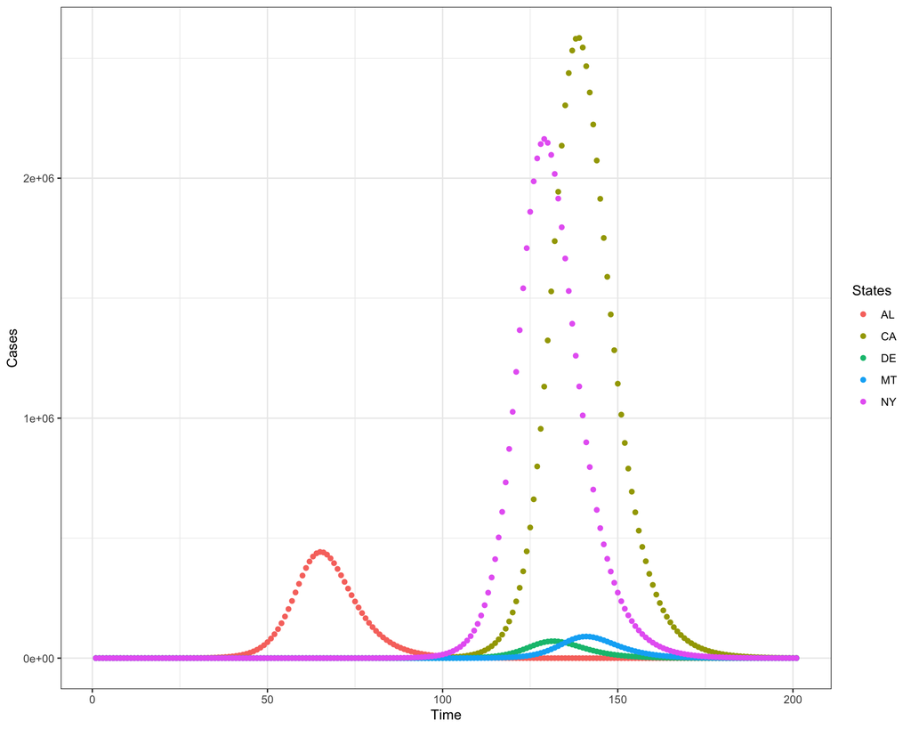

State level epidemics of Flu in the USA using a multipatch SIR model with parameters on spatial interactions based on Viboud et al. 2006. Initial case reported in AL state.

```r
S = usflu$Pop
R = I = rep(0, length(usflu$Pop))
I[1] = 1
usflu$State <- 1:nrow(usflu)
inits = c(S = S, I = I, R = R)

###################################################
# We are then ready to simulate and visualise the model.
require(deSolve)
times = 0:200
out = ode(inits, times, SIR.space, parms)
infected <- as.data.frame(out[, c(51:99)])
get_state_name <- as.data.frame(usflu)
names(infected) <- as.character(usflu$Acronym)
infected$time <- 1:201
infected_long <- melt(infected, id.vars = "time")
state.name <- c("AL", "NY", "MT", "CA", "DE")

ggplot(infected_long %>%
    filter(variable %in% state.name), aes(time, value, col = variable)) +
    geom_point() + theme_bw() + labs(x = "Time", y = "Cases") +
    guides(colour = guide_legend(title = "States"))
```

#### Q14: What are other factors that may explain the spatial synchrony/asynchrony of flu?

**Model answer:**

- Behavioural factors
- Household size
- Immunity
- Vaccination
- Age distribution
- Climatic factors